# Nigeria Crop Production

### Sorghum (NASS 2022)

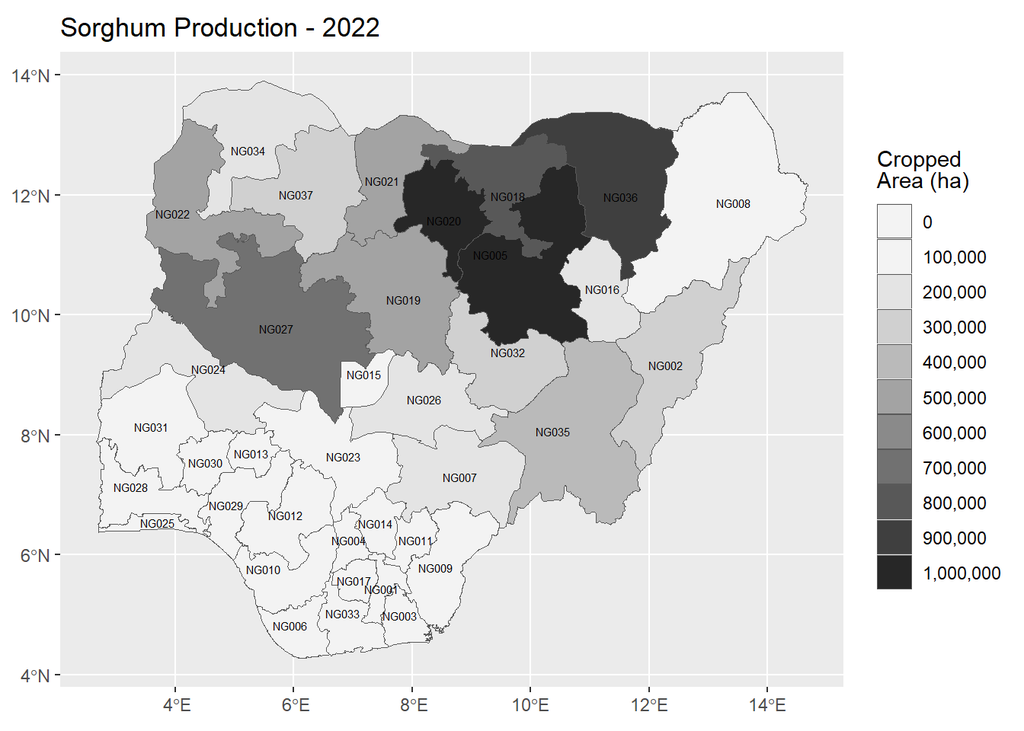

```r
ggplot(vect_sorghum_2022) +
  geom_spatvector(aes(fill = h_area_22_23_T)) +
  geom_spatvector_text(aes(label = adm1_pcode), size = 2) +
  scale_fill_stepsn(
      n.breaks = 10,
      limits = c(0, 1000000),
      colours = hcl.colors(palette = "Grays", 10, rev = T),
      guide = "legend",  na.value = "pink", labels = scales::comma
    ) +
  labs(
    title = "Sorghum Production - 2022",
    fill = "Cropped<br>Area (ha)") +
  theme(
    plot.title = element_markdown(),
    legend.title = element_markdown(),
    axis.title = element_blank()
  )
```

### Sorghum (MapSpam 2020)

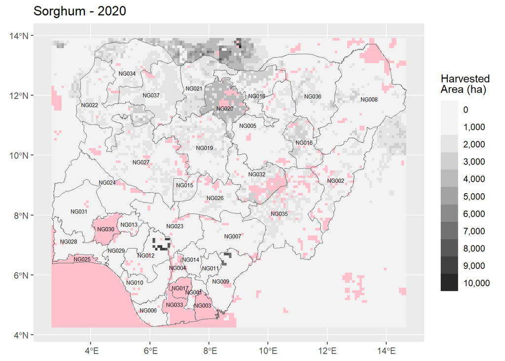

```r
ggplot() +
  geom_spatraster(data = rast_sorghum_spam_2020_nig) +
  geom_spatvector(data = vect_state_geo, fill = NA) +
  geom_spatvector_text(data = vect_state_geo, aes(label = adm1_pcode), size = 2) +
  scale_fill_stepsn(
      n.breaks = 10,
      limits = c(0, 10000),
      colours = hcl.colors(palette = "Grays", 10, rev = T),
      guide = "legend",  na.value = "pink", labels = scales::comma
    ) +
  labs(
    title = "Sorghum - 2020",
    fill = "Harvested<br>Area (ha)") +
  theme(
    plot.title = element_markdown(),
    legend.title = element_markdown(),
    axis.title = element_blank()
  )
```

### Compare sources for Sorghum

The table below displays all four sources together. The data are initially sorted according to the NAERLS data source, and by default the table shows the top 15 states - but you can change the number displayed. You can also change which column to sort by clicking on the arrows, and search for a specific state.

```r
df_sorghum_comb <- dplyr::left_join(
  dplyr::select(
    df_sorghum_2024,
    adm1_pcode,
    adm1_ref_name,
    sorghum_2024
  ),
  dplyr::select(df_sorghum_2023, adm1_pcode, sorghum_2023),
  by = 'adm1_pcode'
) |>
  dplyr::left_join(
    dplyr::select(df_sorghum_2022, sorghum_2022, adm1_ref_name),
    by = 'adm1_ref_name'
  ) |>
  dplyr::left_join(
    df_spam_sorghum_2,
    by = c('adm1_ref_name' = 'ADM1_NAME')
  )

df_sorghum_comb_rename <- df_sorghum_comb |> dplyr::rename(NAERLS_2024 = sorghum_2024, HarvestStat_2023 = sorghum_2023, NASS_2022 = sorghum_2022, MapSpam_2020 = sum_sorghum)


df_sorghum_comb_rename_round <- df_sorghum_comb_rename

df_sorghum_comb_rename_round$NAERLS_2024 <- round(df_sorghum_comb_rename$NAERLS_2024, digits = 0)
df_sorghum_comb_rename_round$HarvestStat_2023 <- round(df_sorghum_comb_rename$HarvestStat_2023, digits = 0)
df_sorghum_comb_rename_round$NASS_2022 <- round(df_sorghum_comb_rename$NASS_2022, digits = 0)
df_sorghum_comb_rename_round$MapSpam_2020 <- round(df_sorghum_comb_rename$MapSpam_2020, digits = 0)

df_sorghum_comb_rename_round |>
  base::sort_by(df_sorghum_comb_rename_round$NAERLS_2024, decreasing = T) |>
  DT::datatable(
    rownames = F,
    filter = "bottom",
    selection = list(mode = "none"),
    editable = FALSE,
    options = list(
      digits = 0,
      scrollX = TRUE,
      scrollCollapse = TRUE,
      autoWidth = TRUE,
      fixedColumns = list(leftColumns = 2),
      lengthMenu = c(15, 40),
      pageLength = 15
    )
  )
```

| adm1_pcode | adm1_ref_name | NAERLS_2024 | HarvestStat_2023 | NASS_2022 | MapSpam_2020 |
| --- | --- | --- | --- | --- | --- |
| NG020 | Kano | 551962 | 524679 | 936408 | 639109 |
| NG026 | Nasarawa | 408806 | 391577 | 131436 | 124973 |
| NG005 | Bauchi | 402336 | 382449 | 1090721 | 276543 |
| NG019 | Kaduna | 344045 | 379322 | 469749 | 380140 |
| NG008 | Borno | 314630 | 314316 | 73293 | 214340 |
| NG037 | Zamfara | 308307 | 339172 | 222051 | 367244 |
| NG035 | Taraba | 304609 | 289552 | 315684 | 335962 |
| NG016 | Gombe | 304275 | 289235 | 111936 | 233466 |
| NG018 | Jigawa | 284238 | 270188 | 759152 | 287583 |
| NG022 | Kebbi | 280743 | 308848 | 400866 | 303244 |

[output cut: 27 more lines]

For sorghum there are some big differences in the harvested area by state between the NAERLS and MapSpam sources. While Kano is the biggest producer in both datasets the difference between Kano and other states is extreme in the MapSpam data, with almost double the area of the next state Kaduna. Other anomalies are Niger and Edo states which have a far higher level of area in MapSpam than the other sources.

NAERLS provides no estimates for many southern states. There is likely to be some production here, perhaps for fodder rather than grain, but these estimates do not appear in the report.

Once again the overall harvested areas in the 2022 NASS source are far larger than in NAERLS. The state with the greatest harvested area is Bauchi, with over one million hectares - far in excess of the values in the NAERLS dataset. In contrast, the values for Borno state are far lower.

Given the more recent data from NAERLS we will use this source for sorghum.

## Sweet Potato

### Sweet Potato (NASS 2022)

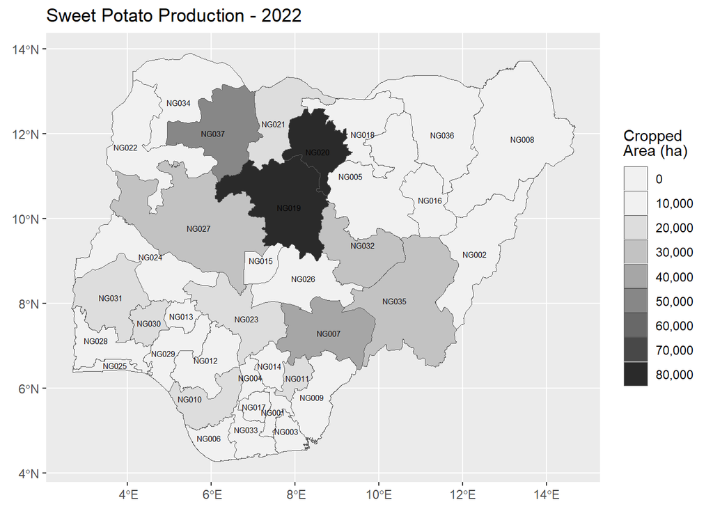

```r
ggplot(vect_spot_2022) +
  geom_spatvector(aes(fill = h_area_22_23_T)) +
  geom_spatvector_text(aes(label = adm1_pcode), size = 2) +
  scale_fill_stepsn(
      n.breaks = 10,
      limits = c(0, 80000),
      colours = hcl.colors(palette = "Grays", 10, rev = T),
      guide = "legend",  na.value = "pink", labels = scales::comma
    ) +
  labs(
    title = "Sweet Potato Production - 2022",
    fill = "Cropped<br>Area (ha)") +
  theme(
    plot.title = element_markdown(),
    legend.title = element_markdown(),
    axis.title = element_blank()
  )
```

### Sweet Potato (HarvestStat 2006)

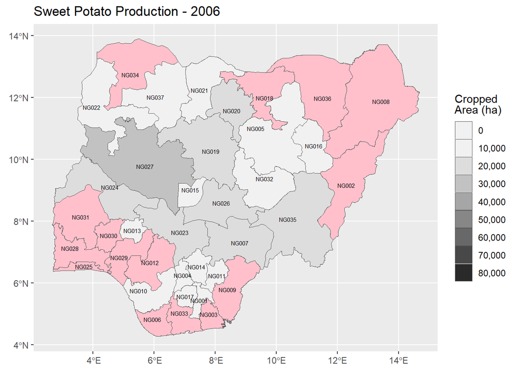

```r
ggplot(vect_spotato_2006) +
  geom_spatvector(aes(fill = value)) +
  geom_spatvector_text(aes(label = adm1_pcode), size = 2) +
  scale_fill_stepsn(
      n.breaks = 10,
      limits = c(0, 80000),
      colours = hcl.colors(palette = "Grays", 10, rev = T),
      guide = "legend",  na.value = "pink", labels = scales::comma
    ) +
  labs(
    title = "Sweet Potato Production - 2006",
    fill = "Cropped<br>Area (ha)") +
  theme(
    plot.title = element_markdown(),
    legend.title = element_markdown(),
    axis.title = element_blank()
  )
```

### Sweet Potato (MapSpam 2020)

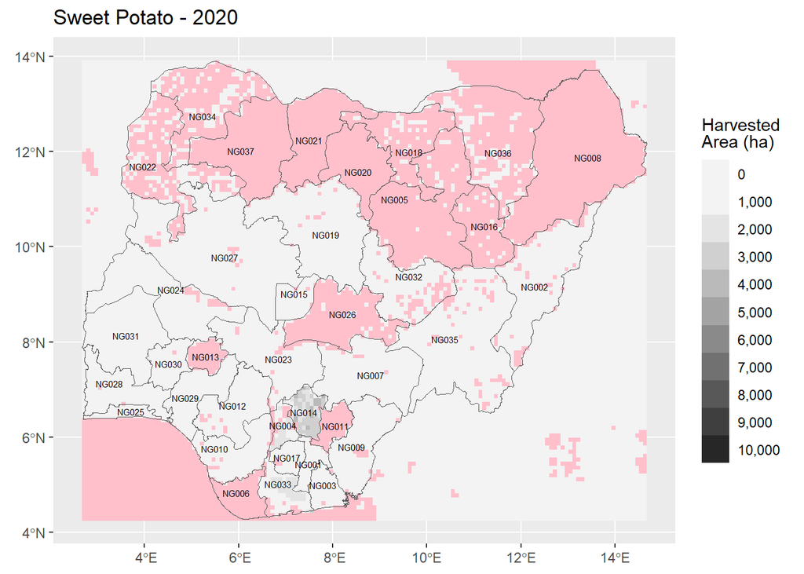

```r
ggplot() +
  geom_spatraster(data = rast_spot_spam_2020_nig) +
  geom_spatvector(data = vect_state_geo, fill = NA) +
  geom_spatvector_text(data = vect_state_geo, aes(label = adm1_pcode), size = 2) +
  scale_fill_stepsn(
      n.breaks = 10,
      limits = c(0, 10000),
      colours = hcl.colors(palette = "Grays", 10, rev = T),
      guide = "legend",  na.value = "pink", labels = scales::comma
    ) +
  labs(
    title = "Sweet Potato - 2020",
    fill = "Harvested<br>Area (ha)") +
  theme(
    plot.title = element_markdown(),
    legend.title = element_markdown(),
    axis.title = element_blank()
  )
```

### Compare sources for Sweet Potato

The table below displays three sources together. The data are initially sorted according to the HarvestStat data source, and by default the table shows the top 15 states - but you can change the number displayed. You can also change which column to sort by clicking on the arrows, and search for a specific state.

```r
df_spotato_comb <- dplyr::left_join(
  dplyr::select(
    df_spotato_2006,
    adm1_pcode,
    adm1_ref_name,
    spotato_2006
  ),
    dplyr::select(df_sorghum_2022, sorghum_2022, adm1_ref_name),
    by = 'adm1_ref_name'
  ) |>
  dplyr::left_join(
    df_spam_spot_2,
    by = c('adm1_ref_name' = 'ADM1_NAME')
  )


df_spotato_comb_rename <- df_spotato_comb |> dplyr::rename(NASS_2022 = sorghum_2022, HarvestStat_2006 = spotato_2006, MapSpam_2020 = sum_spot)

df_spotato_comb_rename_round <- df_spotato_comb_rename

df_spotato_comb_rename_round$NASS_2022 <- round(df_spotato_comb_rename$NASS_2022, digits = 0)
df_spotato_comb_rename_round$HarvestStat_2006 <- round(df_spotato_comb_rename$HarvestStat_2006, digits = 0)
df_spotato_comb_rename_round$MapSpam_2020 <- round(df_spotato_comb_rename$MapSpam_2020, digits = 0)

df_spotato_comb_rename_round |>
  base::sort_by(df_spotato_comb_rename_round$HarvestStat_2006, decreasing = T) |>
  DT::datatable(
    rownames = F,
    filter = "bottom",
    selection = list(mode = "none"),
    editable = FALSE,
    options = list(
      digits = 0,
      scrollX = TRUE,
      scrollCollapse = TRUE,
      autoWidth = TRUE,
      fixedColumns = list(leftColumns = 2),
      lengthMenu = c(15, 40),
      pageLength = 15
    )
  )
```

| adm1_pcode | adm1_ref_name | HarvestStat_2006 | NASS_2022 | MapSpam_2020 |
| --- | --- | --- | --- | --- |
| NG027 | Niger | 25840 | 611306 | 180381 |
| NG007 | Benue | 19800 | 169796 | 161774 |
| NG035 | Taraba | 16320 | 315684 | 149865 |
| NG026 | Nasarawa | 14050 | 131436 | 0 |
| NG019 | Kaduna | 11790 | 469749 | 126391 |
| NG020 | Kano | 10790 | 936408 | 0 |
| NG024 | Kwara | 10500 | 126040 | 26292 |
| NG023 | Kogi | 10100 | 64930 | 64949 |
| NG032 | Plateau | 9720 | 264238 | 75177 |
| NG005 | Bauchi | 8670 | 1090721 | 0 |

[output cut: 27 more lines]

The comparison between the 2006 estimates from HarvestStat and those of 2020 from MapSpam show very large differences in the absolute harvested areas, with many states in the 2020 dataset showing areas an order of magnitude different, such as Niger, Benue and Taraba, or more extremely for Enugu.

Sweet Potato production has increased in Nigeria, and the 2006 data are now very old. While the MapSpam data show unusual patterns and obvious missing data for Bayelsa, Ebonyi, Ekiti and Nasarawa. The MapSpam data are more recent than the 2006 data, but given the more recent data in NASS those data will be used for Sweet Potato.

# Conclusions

It is therefore necessary to use a mixture of the sources, with government sources and more recent data given a higher priority ( Table 2 ).

Table 2: Selected Crop Production data sources for Nigeria

Source

Spatial Resolution

Most recent data

Crops (selected)

Indicators

NAERLS/FMAFS

State

2024

- **Banana/Plantain**
- **Rice**
- **Sorghum**
- Area
- Production
- Yield

NBS/NASS

State

2022

- **Cassava**
- **Cowpea**
- **Maize**
- **Sweet Potato**
- Harvest Area
- Production
- Yield

MapSpam

5’ Pixel

2020

- Harvest Area
- Production
- Yield

These are saved to the local database.

For the Biofortification Prioritisation Index we do not use the harvested area of a particular crop directly, instead we require the proportion of the state’s cropland dedicated to the crop. Also, in the weighting of the BPI we need to calculate the state’s share of the national production of a specific crop.

This has implications when we use crop statistics from different sources. Ideally we would use a single source, which had all crop harvested areas for all states. We do not mix the data from different sources, but there is the possibility of achieving state level proportions that sum to more then 100%, e.g.

| Crop | Harvest Area | Total (a) or (b) | Proportion % |
| --- | --- | --- | --- |
| Banana/Plantain (a) | 100 | 1000 | 10 |
| Cassava (b) | 500 | 2000 | 25 |
| Cowpea (b) | 100 | 2000 | 5 |
| Maize (b) | 500 | 2000 | 25 |
| Rice (a) | 300 | 1000 | 30 |
| Sorghum (a) | 100 | 1000 | 10 |
| Sweet Potato (b) | 100 | 2000 | 5 |
|  |  |  | 110 |

This will not have an effect for an individual crop BPI, but would have the effect of prioritising certain states that have large and differing harvested areas for different crops in different databases.

```r
## NAERLS data source

# # plantain banana 2024
# writeVector(
#   x = vect_plantain_banana_2024,
#   filename = "E:/repos/Nigeria_Biofortification_Atlas/spatial_data/plantain_banana_2024_naerls.geojson",
#   filetype = "GeoJSON",
#   overwrite = TRUE
# )
#
#
# # Rice 2024
# writeVector(
#   x = vect_rice_2024,
#   filename = "E:/repos/Nigeria_Biofortification_Atlas/spatial_data/rice_2024_naerls.geojson",
#   filetype = "GeoJSON",
#   overwrite = TRUE
# )
#
# # Sorghum 2024
# writeVector(
#   x = vect_sorghum_2024,
#   filename = "E:/repos/Nigeria_Biofortification_Atlas/spatial_data/sorghum_2024_naerls.geojson",
#   filetype = "GeoJSON",
#   overwrite = TRUE
# )


## NASS data source

# # Cassava 2022
 writeVector(
   x = vect_cassava_2022,
   filename = "E:/repos/Nigeria_Biofortification_Atlas/spatial_data/cassava_2022_nass.geojson",
   filetype = "GeoJSON",
   overwrite = TRUE
 )

# # Cowpea 2022
writeVector(
   x = vect_cowpea_2022,
   filename = "E:/repos/Nigeria_Biofortification_Atlas/spatial_data/cowpea_2022_nass.geojson",
   filetype = "GeoJSON",
   overwrite = TRUE
 )

# # Maize 2022
 writeVector(
   x = vect_maize_2022,
   filename = "E:/repos/Nigeria_Biofortification_Atlas/spatial_data/maize_2022_nass.geojson",
   filetype = "GeoJSON",
   overwrite = TRUE
 )

# Sweet Potato 2022
writeVector(
  x = vect_spot_2022,
  filename = "E:/repos/Nigeria_Biofortification_Atlas/spatial_data/spot_2022_nass.geojson",
  filetype = "GeoJSON",
  overwrite = TRUE
)
```

# Crop Area as percentage of total area harvested in the state

```r
# # plantain banana 2024
vect_plantain_banana_2024 <- vect("E:/repos/Nigeria_Biofortification_Atlas/spatial_data/plantain_banana_2024_naerls.geojson")

df_plantain_banana_2024_rename <- as.data.frame(vect_plantain_banana_2024) |>
  rename(plantain_banana_Area_2024 = Area_Ha_2024) |> select(adm1_ref_name, plantain_banana_Area_2024)


# # Cassava 2022
vect_cassava_2022 <- vect("E:/repos/Nigeria_Biofortification_Atlas/spatial_data/cassava_2022_nass.geojson")

df_cassava_2022_rename <- as.data.frame(vect_cassava_2022) |>
  rename(cassava_Area_2022 = h_area_22_23_T) |> select(adm1_ref_name, cassava_Area_2022)


# # Cowpea 2022
vect_cowpea_2022 <- vect("E:/repos/Nigeria_Biofortification_Atlas/spatial_data/cowpea_2022_nass.geojson")

df_cowpea_2022_rename <- as.data.frame(vect_cowpea_2022) |>
  rename(cowpea_Area_2022 = h_area_22_23_T) |> select(adm1_ref_name, cowpea_Area_2022)


# # Maize 2022
vect_maize_2022 <- vect("E:/repos/Nigeria_Biofortification_Atlas/spatial_data/maize_2022_nass.geojson" )

df_maize_2022_rename <- as.data.frame(vect_maize_2022) |>
  rename(maize_Area_2022 = h_area_22_23_T) |> select(adm1_ref_name, maize_Area_2022)


# # Rice 2024
vect_rice_2024 <- vect("E:/repos/Nigeria_Biofortification_Atlas/spatial_data/rice_2024_naerls.geojson")

df_rice_2024_rename <- as.data.frame(vect_rice_2024) |>
  rename(rice_Area_2024 = Area_Ha_2024) |> select(adm1_ref_name, rice_Area_2024)


# # Sorghum 2024
vect_sorghum_2024 <- vect("E:/repos/Nigeria_Biofortification_Atlas/spatial_data/sorghum_2024_naerls.geojson")

df_sorghum_2024_rename <- as.data.frame(vect_sorghum_2024) |>
  rename(sorghum_Area_2024 = Area_Ha_2024) |> select(adm1_ref_name, sorghum_Area_2024)


# Sweet Potato MapSpam 2020
vect_spot_2022 <- vect("E:/repos/Nigeria_Biofortification_Atlas/spatial_data/spot_2022_nass.geojson")

df_spot_2022_rename <- as.data.frame(vect_spot_2022) |>
  rename(spot_Area_2022 = h_area_22_23_T) |> select(adm1_ref_name, spot_Area_2022)
```

```r
df_crop_share <-
  left_join(
    select(df_total_cropped_2024, adm1_ref_name, Area_Ha_2024),
    df_plantain_banana_2024_rename,
    by = "adm1_ref_name"
  ) |>
  left_join(df_cassava_2022_rename, by = "adm1_ref_name") |>
  left_join(df_cowpea_2022_rename, by = "adm1_ref_name") |>
  left_join(df_maize_2022_rename, by = "adm1_ref_name") |>
  left_join(df_rice_2024_rename, by = "adm1_ref_name") |>
  left_join(df_sorghum_2024_rename, by = "adm1_ref_name") |>
  left_join(df_spot_2022_rename, by = "adm1_ref_name") |>
  left_join(
    rename(df_nass_total_cropped, Area_Ha_2022 = sum_area),
    by = "adm1_ref_name"
  )

df_crop_share <- df_crop_share |>
  mutate(plantain_banana_share_2024 = (plantain_banana_Area_2024/Area_Ha_2024) * 100,
         cassava_share_2022 = (cassava_Area_2022/Area_Ha_2022) * 100,
         cowpea_share_2022 = (cowpea_Area_2022/Area_Ha_2022) * 100,
         maize_share_2022 = (maize_Area_2022/Area_Ha_2022) * 100,
         rice_share_2024 = (rice_Area_2024/Area_Ha_2024) * 100,
         sorghum_share_2024 = (sorghum_Area_2024/Area_Ha_2024) * 100,
         spot_share_2022 = (spot_Area_2022/Area_Ha_2022) * 100)

vect_crop_area_share <- dplyr::left_join(vect_state_geo, df_crop_share , by = c("adm1_ref_name"))
```

## Banana/Plantain crop area share

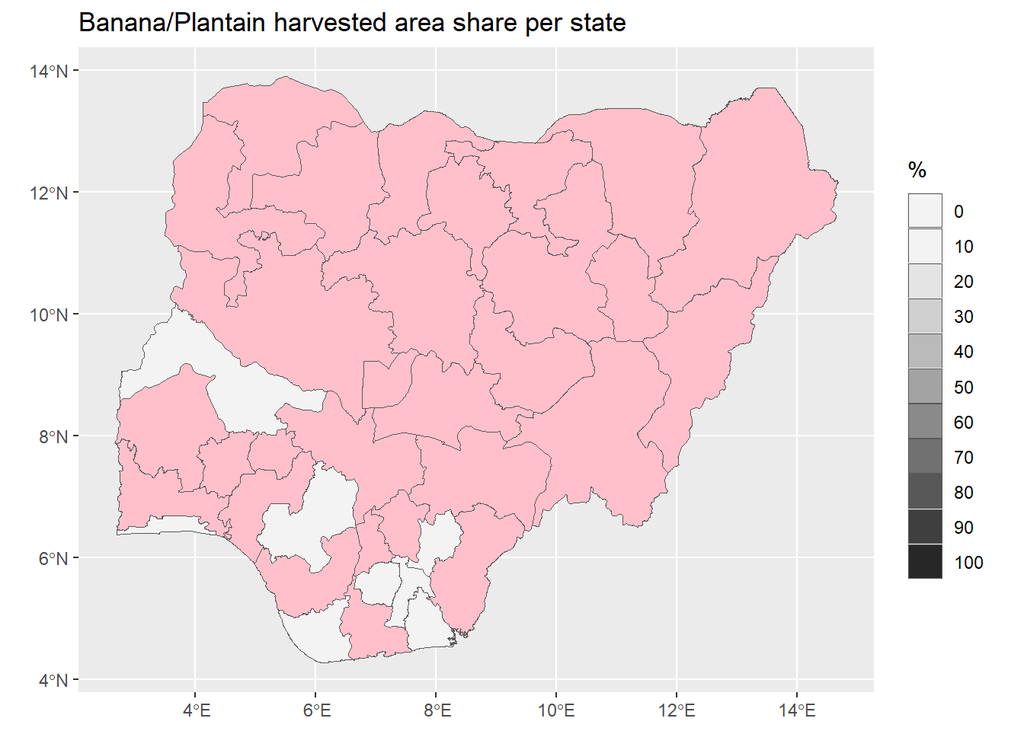

```r
ggplot(vect_crop_area_share) +
  geom_spatvector(aes(fill = plantain_banana_share_2024)) +
  scale_fill_stepsn(
    n.breaks = 10,
    limits = c(0, 100),
    colours = hcl.colors(palette = "Grays", 10, rev = T),
    guide = "legend",
    na.value = "pink",
    labels = scales::comma
  ) +
  labs(title = "Banana/Plantain harvested area share per state", fill = "%") +
  theme(
    plot.title = element_markdown(),
    legend.title = element_markdown(),
    axis.title = element_blank()
  )
```

## Cassava crop area share

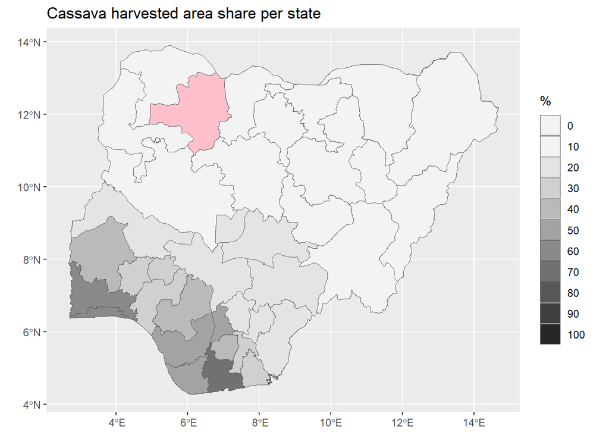

```r
ggplot(vect_crop_area_share) +
  geom_spatvector(aes(fill = cassava_share_2022)) +
  scale_fill_stepsn(
    n.breaks = 10,
    limits = c(0, 100),
    colours = hcl.colors(palette = "Grays", 10, rev = T),
    guide = "legend",
    na.value = "pink",
    labels = scales::comma
  ) +
  labs(title = "Cassava harvested area share per state", fill = "%") +
  theme(
    plot.title = element_markdown(),
    legend.title = element_markdown(),
    axis.title = element_blank()
  )
```

## Cowpea crop area share

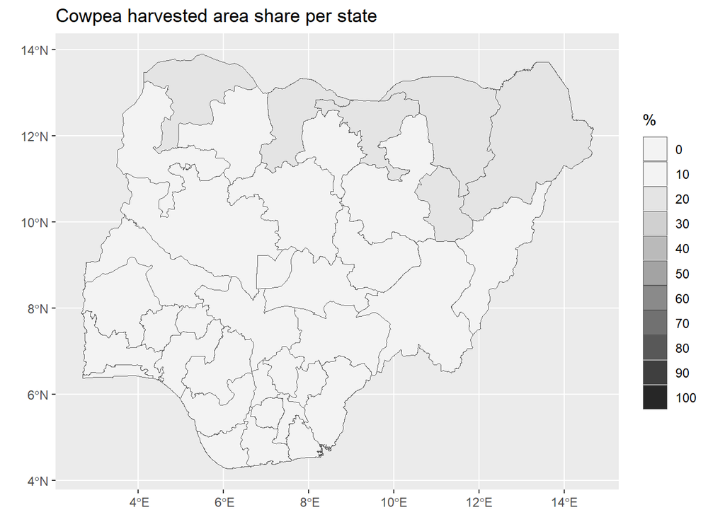

```r
ggplot(vect_crop_area_share) +
  geom_spatvector(aes(fill = cowpea_share_2022)) +
  scale_fill_stepsn(
    n.breaks = 10,
    limits = c(0, 100),
    colours = hcl.colors(palette = "Grays", 10, rev = T),
    guide = "legend",
    na.value = "pink",
    labels = scales::comma
  ) +
  labs(title = "Cowpea harvested area share per state", fill = "%") +
  theme(
    plot.title = element_markdown(),
    legend.title = element_markdown(),
    axis.title = element_blank()
  )
```

## Maize crop area share

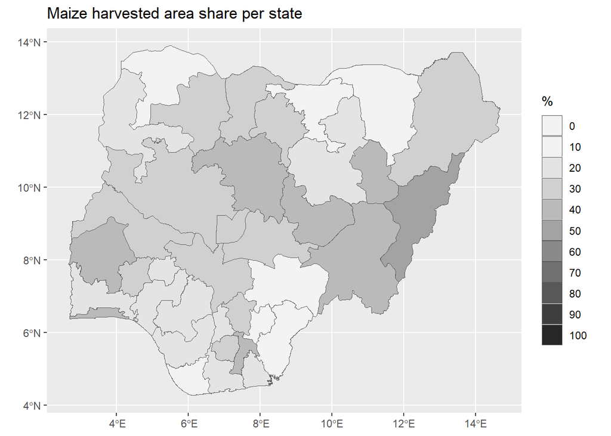

```r
ggplot(vect_crop_area_share) +
  geom_spatvector(aes(fill = maize_share_2022)) +
  scale_fill_stepsn(
    n.breaks = 10,
    limits = c(0, 100),
    colours = hcl.colors(palette = "Grays", 10, rev = T),
    guide = "legend",
    na.value = "pink",
    labels = scales::comma
  ) +
  labs(title = "Maize harvested area share per state", fill = "%") +
  theme(
    plot.title = element_markdown(),
    legend.title = element_markdown(),
    axis.title = element_blank()
  )
```

## Rice crop area share

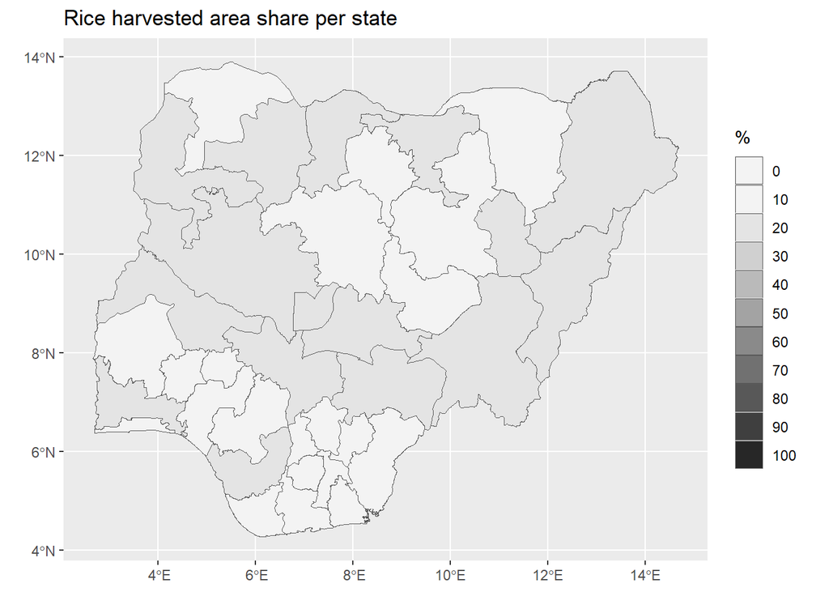

```r
ggplot(vect_crop_area_share) +
  geom_spatvector(aes(fill = rice_share_2024)) +
  scale_fill_stepsn(
    n.breaks = 10,
    limits = c(0, 100),
    colours = hcl.colors(palette = "Grays", 10, rev = T),
    guide = "legend",
    na.value = "pink",
    labels = scales::comma
  ) +
  labs(title = "Rice harvested area share per state", fill = "%") +
  theme(
    plot.title = element_markdown(),
    legend.title = element_markdown(),
    axis.title = element_blank()
  )
```

## Sorghum crop area share

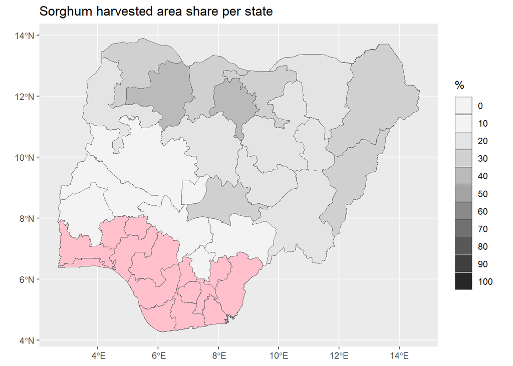

```r
ggplot(vect_crop_area_share) +
  geom_spatvector(aes(fill = sorghum_share_2024)) +
  scale_fill_stepsn(
    n.breaks = 10,
    limits = c(0, 100),
    colours = hcl.colors(palette = "Grays", 10, rev = T),
    guide = "legend",
    na.value = "pink",
    labels = scales::comma
  ) +
  labs(title = "Sorghum harvested area share per state", fill = "%") +
  theme(
    plot.title = element_markdown(),
    legend.title = element_markdown(),
    axis.title = element_blank()
  )
```

## Sweet Potato crop area share

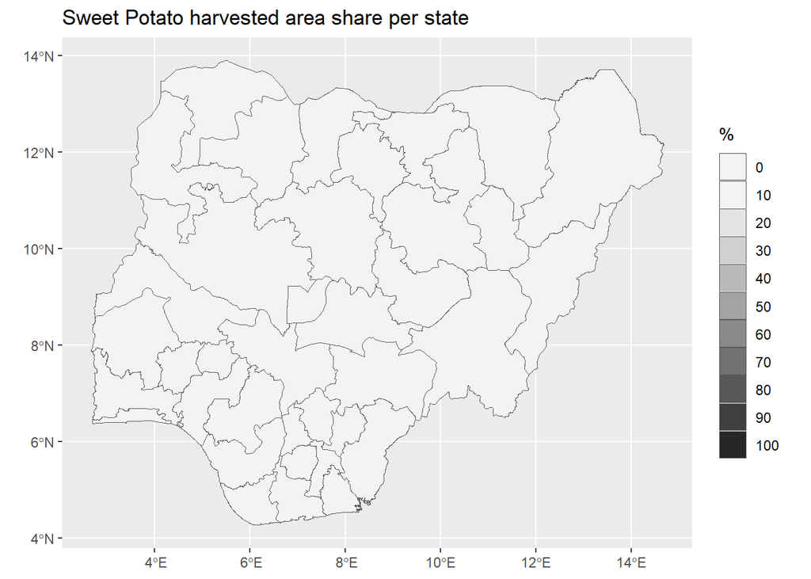

```r
ggplot(vect_crop_area_share) +
  geom_spatvector(aes(fill = spot_share_2022)) +
  scale_fill_stepsn(
    n.breaks = 10,
    limits = c(0, 100),
    colours = hcl.colors(palette = "Grays", 10, rev = T),
    guide = "legend",
    na.value = "pink",
    labels = scales::comma
  ) +
  labs(title = "Sweet Potato harvested area share per state", fill = "%") +
  theme(
    plot.title = element_markdown(),
    legend.title = element_markdown(),
    axis.title = element_blank()
  )
```

# Per-capita area harvested

We use the same population data for all crops (regardless of the date of the crop harvested area). For our purposes we are most interested in the differences among geographic units rather than between crops.

We decided to use our extrapolation of population from the NBS figures to 2025.

## 2025 and 2030 state population estimates

```r
df_pop_nbs <- read.csv("tab_data/nigeria_state_population_weights_2025_2030_csv.csv")
vect_state_geo_nbs <- tidyterra::left_join(vect_state_geo, df_pop_nbs, by = c( "adm1_ref_name" = "state_name"))
```

## Total Population - Extrapolated from NBS 2016

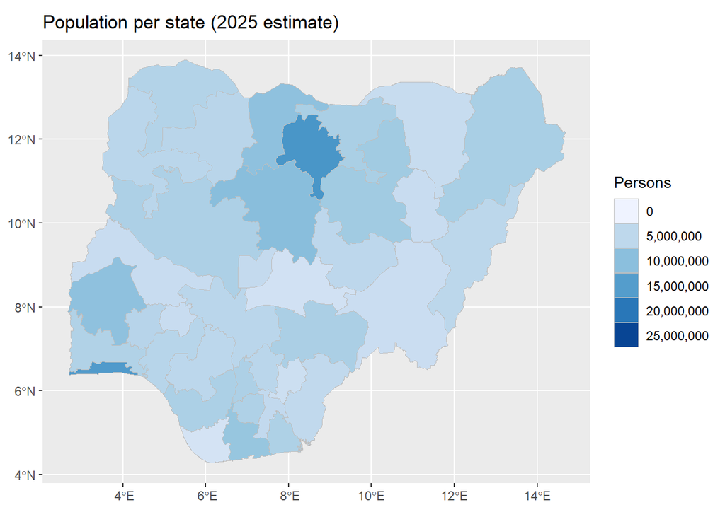

Figure 1: NBS 2025 estimates of population per state

```r
#

ggplot() +
  geom_spatvector(data = vect_state_geo_nbs, aes(fill = pop_est_2025), colour = "grey") +
  scale_fill_distiller(
        type = "seq",
        palette = "Blues",
        direction = 1,
        limits = c(0, 25000000),
        labels = label_comma(),
        guide = "legend"
      ) +
  labs(title = "Population per state (2025 estimate)", fill = "Persons") +
  theme(
    plot.title = element_markdown(),
    legend.title = element_markdown(),
    axis.title = element_blank()
  )
```

```r
df_crop_per_capita_pc <- left_join(df_crop_share, select(df_pop_nbs, state_name, pop_est_2025 ), by = c("adm1_ref_name" = "state_name"))

df_crop_per_capita_pc <- df_crop_per_capita_pc |>
  mutate(plantain_banana_pc_2024 = (plantain_banana_Area_2024/pop_est_2025) * 10000,
         cassava_pc_2022 = (cassava_Area_2022/pop_est_2025) * 10000,
         cowpea_pc_2022 = (cowpea_Area_2022/pop_est_2025) * 10000,
         maize_pc_2022 = (maize_Area_2022/pop_est_2025) * 10000,
         rice_pc_2024 = (rice_Area_2024/pop_est_2025) * 10000,
         sorghum_pc_2024 = (sorghum_Area_2024/pop_est_2025) * 10000,
         spot_pc_2022 = (spot_Area_2022/pop_est_2025) * 10000)

vect_crop_area_pc <- dplyr::left_join(vect_state_geo, df_crop_per_capita_pc , by = c("adm1_ref_name"))
```

## Banana/Plantain crop area per capita

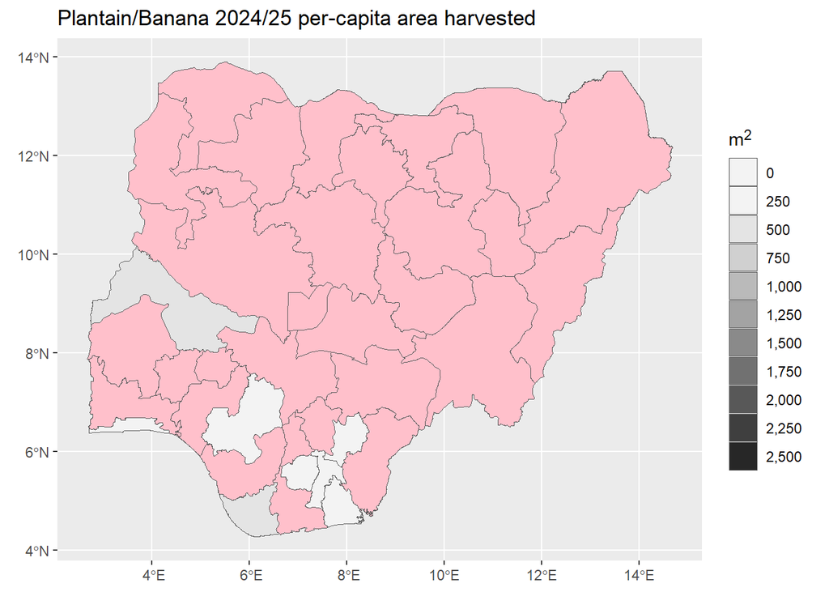

Figure 2: Plantain/Banana 2024/25 per-capita area harvested

```r
#

ggplot(vect_crop_area_pc) +
  geom_spatvector(aes(fill = plantain_banana_pc_2024)) +
  scale_fill_stepsn(
    n.breaks = 10,
    limits = c(0, 2500),
    colours = hcl.colors(palette = "Grays", 10, rev = T),
    guide = "legend",
    na.value = "pink",
    labels = scales::comma
  ) +
  labs(title = "Plantain/Banana 2024/25 per-capita area harvested", fill = "m<sup>2</sup>") +
  theme(
    plot.title = element_markdown(),
    legend.title = element_markdown(),
    axis.title = element_blank()
  )
```

## Cassava crop area per capita

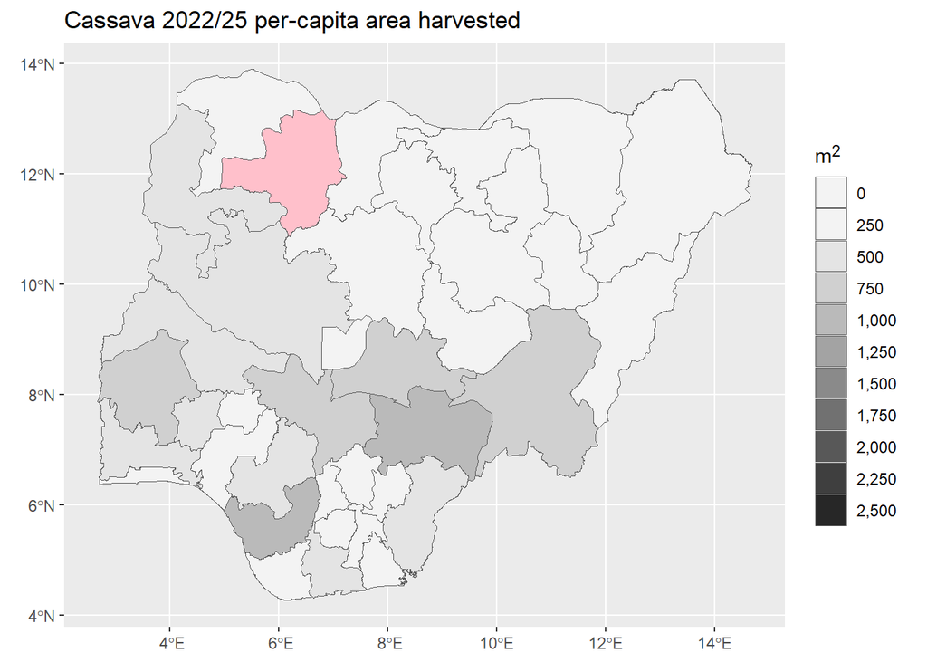

Figure 3: Cassava 2022/25 per-capita area harvested

```r
#

ggplot(vect_crop_area_pc) +
  geom_spatvector(aes(fill = cassava_pc_2022)) +
  scale_fill_stepsn(
    n.breaks = 10,
    limits = c(0, 2500),
    colours = hcl.colors(palette = "Grays", 10, rev = T),
    guide = "legend",
    na.value = "pink",
    labels = scales::comma
  ) +
  labs(title = "Cassava 2022/25 per-capita area harvested", fill = "m<sup>2</sup>") +
  theme(
    plot.title = element_markdown(),
    legend.title = element_markdown(),
    axis.title = element_blank()
  )
```

## Cowpea crop area per capita

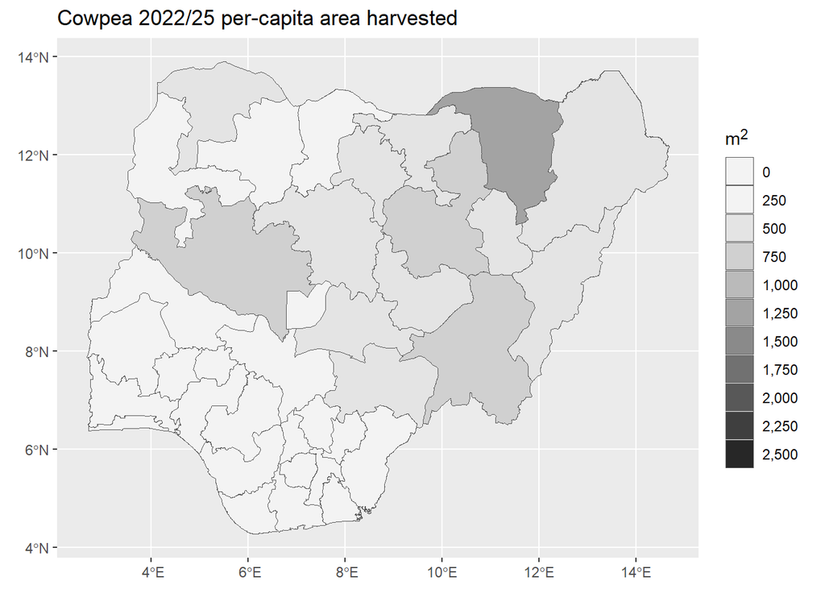

Figure 4: Cowpea 2022/25 per-capita area harvested

```r
#

ggplot(vect_crop_area_pc) +
  geom_spatvector(aes(fill = cowpea_pc_2022)) +
  scale_fill_stepsn(
    n.breaks = 10,
    limits = c(0, 2500),
    colours = hcl.colors(palette = "Grays", 10, rev = T),
    guide = "legend",
    na.value = "pink",
    labels = scales::comma
  ) +
  labs(title = "Cowpea 2022/25 per-capita area harvested", fill = "m<sup>2</sup>") +
  theme(
    plot.title = element_markdown(),
    legend.title = element_markdown(),
    axis.title = element_blank()
  )
```

## Maize crop area per capita

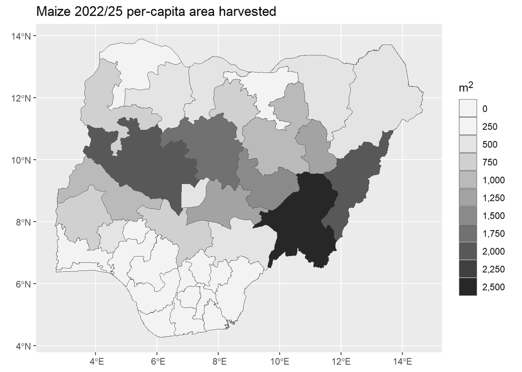

Figure 5: Maize 2022/25 per-capita area harvested

```r
#

ggplot(vect_crop_area_pc) +
  geom_spatvector(aes(fill = maize_pc_2022)) +
  scale_fill_stepsn(
    n.breaks = 10,
    limits = c(0, 2500),
    colours = hcl.colors(palette = "Grays", 10, rev = T),
    guide = "legend",
    na.value = "pink",
    labels = scales::comma
  ) +
  labs(title = "Maize 2022/25 per-capita area harvested", fill = "m<sup>2</sup>") +
  theme(
    plot.title = element_markdown(),
    legend.title = element_markdown(),
    axis.title = element_blank()
  )
```

## Sorghum crop area per capita

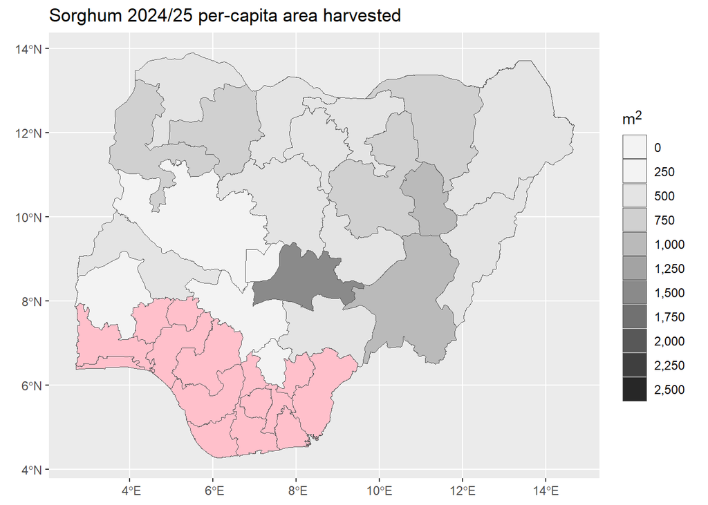

Figure 6: Sorghum 2024/25 per-capita area harvested

```r
#

ggplot(vect_crop_area_pc) +
  geom_spatvector(aes(fill = sorghum_pc_2024)) +
  scale_fill_stepsn(
    n.breaks = 10,
    limits = c(0, 2500),
    colours = hcl.colors(palette = "Grays", 10, rev = T),
    guide = "legend",
    na.value = "pink",
    labels = scales::comma
  ) +
  labs(title = "Sorghum 2024/25 per-capita area harvested", fill = "m<sup>2</sup>") +
  theme(
    plot.title = element_markdown(),
    legend.title = element_markdown(),
    axis.title = element_blank()
  )
```

## Sweet Potato crop area per capita

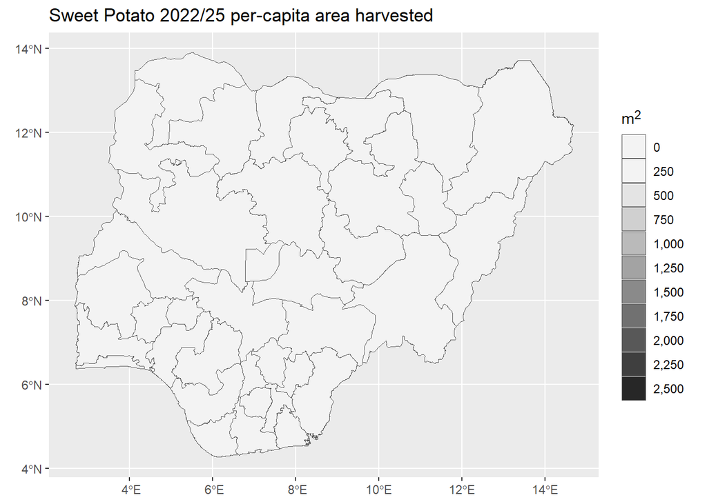

Figure 7: Sweet Potato 2022/25 per-capita area harvested

```r
#

ggplot(vect_crop_area_pc) +
  geom_spatvector(aes(fill = spot_pc_2022)) +
  scale_fill_stepsn(
    n.breaks = 10,
    limits = c(0, 2500),
    colours = hcl.colors(palette = "Grays", 10, rev = T),
    guide = "legend",
    na.value = "pink",
    labels = scales::comma
  ) +
  labs(title = "Sweet Potato 2022/25 per-capita area harvested", fill = "m<sup>2</sup>") +
  theme(
    plot.title = element_markdown(),
    legend.title = element_markdown(),
    axis.title = element_blank()
  )
```

```r
# crop share
writeVector(
  x = vect_crop_area_share,
  filename = "spatial_data/vect_crop_area_share.geojson",
  filetype = "GeoJSON",
  overwrite = TRUE
)

# crop per capita
writeVector(
  x = vect_crop_area_pc,
  filename = "spatial_data/vect_crop_area_pc.geojson",
  filetype = "GeoJSON",
  overwrite = TRUE
)
```

# Crop area per state as proportion of national total

## Plantain/Banana national area share

```r
plantain_banana_area_2024_total <-
  df_plantain_banana_2024_rename |>
  dplyr::summarise(total = sum(plantain_banana_Area_2024, na.rm=T)) |> pull(total)

df_plantain_banana_2024_national_share <- df_plantain_banana_2024_rename |>
  mutate(plantain_banana_Area_2024_pc = (plantain_banana_Area_2024 / plantain_banana_area_2024_total))

df_plantain_banana_2024_national_share[is.na(df_plantain_banana_2024_national_share)] <- 0

write.csv(df_plantain_banana_2024_national_share, "tab_data/plantain_banana_area_national_share_2024.csv")
```

## Cassava national area share

```r
cassava_area_2022_total <-
  df_cassava_2022_rename |>
  dplyr::summarise(total = sum(cassava_Area_2022, na.rm=T)) |> pull(total)

df_cassava_2022_national_share <- df_cassava_2022_rename |>
  mutate(cassava_Area_2022_pc = (cassava_Area_2022 / cassava_area_2022_total))

df_cassava_2022_national_share[is.na(df_cassava_2022_national_share)] <- 0

write.csv(df_cassava_2022_national_share, "tab_data/cassava_area_national_share_2022.csv")
```

## Cowpea national area share

```r
cowpea_area_2022_total <-
  df_cowpea_2022_rename |>
  dplyr::summarise(total = sum(cowpea_Area_2022, na.rm=T)) |> pull(total)

df_cowpea_2022_national_share <- df_cowpea_2022_rename |>
  mutate(cowpea_Area_2022_pc = (cowpea_Area_2022 / cowpea_area_2022_total))

df_cowpea_2022_national_share[is.na(df_cowpea_2022_national_share)] <- 0

write.csv(df_cowpea_2022_national_share, "tab_data/cowpea_area_national_share_2022.csv")
```

## Maize national area share

```r
maize_area_2022_total <-
  df_maize_2022_rename |>
  dplyr::summarise(total = sum(maize_Area_2022, na.rm=T)) |> pull(total)

df_maize_2022_national_share <- df_maize_2022_rename |>
  mutate(maize_Area_2022_pc = (maize_Area_2022 / maize_area_2022_total))

df_maize_2022_national_share[is.na(df_maize_2022_national_share)] <- 0

write.csv(df_maize_2022_national_share, "tab_data/maize_area_national_share_2022.csv")
```

## Rice national area share

```r
rice_area_2024_total <-
  df_rice_2024_rename |>
  dplyr::summarise(total = sum(rice_Area_2024, na.rm=T)) |> pull(total)

df_rice_2024_national_share <- df_rice_2024_rename |>
  mutate(rice_Area_2024_pc = (rice_Area_2024 / rice_area_2024_total))

df_rice_2024_national_share[is.na(df_rice_2024_national_share)] <- 0

write.csv(df_rice_2024_national_share, "tab_data/rice_area_national_share_2024.csv")
```

## Sorghum national area share

```r
sorghum_area_2024_total <-
  df_sorghum_2024_rename |>
  dplyr::summarise(total = sum(sorghum_Area_2024, na.rm=T)) |> pull(total)

df_sorghum_2024_national_share <- df_sorghum_2024_rename |>
  mutate(sorghum_Area_2024_pc = (sorghum_Area_2024 / sorghum_area_2024_total))

df_sorghum_2024_national_share[is.na(df_sorghum_2024_national_share)] <- 0

write.csv(df_sorghum_2024_national_share, "tab_data/sorghum_area_national_share_2024.csv")
```

## Sweet Potato national area share

```r
spot_area_2022_total <-
  df_spot_2022_rename |>
  dplyr::summarise(total = sum(spot_Area_2022, na.rm=T)) |> pull(total)

df_spot_2022_national_share <- df_spot_2022_rename |>
  mutate(spot_Area_2022_pc = (spot_Area_2022 / spot_area_2022_total))

df_spot_2022_national_share[is.na(df_spot_2022_national_share)] <- 0

write.csv(df_spot_2022_national_share, "tab_data/spot_area_national_share_2022.csv")
```

## References

Lee, D., W. Anderson, X. Chen, et al. 2025. “HarvestStat Africa - Harmonized Subnational Crop Statistics for Sub-Saharan Africa.” *Sci Data* 12 (1): 690. https://doi.org/10.1038/s41597-025-05001-z.

NAERLS/FMAFS. 2024. *2024 Wet Season Agricultural Performance in Nigeria: National Report*. National Agricultural Extension and Research Liaison Services, Ahmadu Bello University and Federal Ministry of Agriculture and Food Security.

You, L., S. Wood, U. Wood-Sichra, and W. Wu. 2014. “Generating Global Crop Distribution Maps: From Census to Grid.” *Agricultural Systems* 127: 53–60. https://doi.org/10.1016/j.agsy.2014.01.002.

Zanaga, D., R. Van De Kerchove, D. Daems, et al. 2022. *ESA WorldCover 10 m 2021 V200*. https://doi.org/10.5281/zenodo.7254221.